# Tenth Week: Principal Component Analysis and Factor Analysis

PCA Stock, image, …

Amirabbas Jalali 93105556

2018-05-21 01:16:29

> با استفاده از داده های OHLCV شرکت های تشکیل دهنده شاخص s&p500 و همچنین داده مربوط به شاخص های اقتصادی به سوالات زیر پاسخ دهید.

داده ها و کتابخانه های زیر در طول تمرین مورد استفاده قرارخواهندگرفت.

```r
library(dplyr)
library(readr)
library(highcharter)
library(stringr)
library(lubridate)
library(ggplot2)

name = list.files("../../Data/Stock/stock_dfs/") %>% str_replace(".csv","")
textpath = list.files("../../Data/Stock/stock_dfs", full.names = T)
constituents = read_csv("../../Data/Stock/constituents.csv")
indexes = read_csv("../../Data/Stock/indexes.csv")

.data <- read_csv(textpath[1]) %>% select(Date, Open, High, Low, Close, Volume)
.data$Name = name[1]
sp500 = .data

for(i in 2:length(name)){
  .data <- read_csv(textpath[i]) %>% select(Date, Open, High, Low, Close, Volume)
  .data$Name = name[i]
  sp500 = bind_rows(sp500, .data)
}

sp500 = sp500 %>%
  mutate(year = year(Date), month = month(Date), day = day(Date))

.data <- read_csv(textpath[1]) %>% select(Date, Open)
colnames(.data) =c("Date", name[1])
sp500_pca = .data

for(i in 2:length(name)){
  .data <- read_csv(textpath[i]) %>% select(Date, Open)
  colnames(.data) =c("Date", name[i])
  sp500_pca = merge(sp500_pca, .data)
}

sp500_pca= sp500_pca %>%
  mutate(year = year(Date), month = month(Date), day = day(Date))
```

۱. چه شرکتی رکورددار کسب بیشترین سود در بازه یکساله، دو ساله و پنج ساله می باشد؟ این سوال را برای بخش های مختلف مورد مطالعه قرار دهید و رکورددار را معرفی کنید. (برای این کار به ستون sector داده constituents مراجعه کنید.) برای هر دو قسمت نمودار سود ده شرکت و یا بخش برتر را رسم نمایید.

جواب:  
در این سوال در هر بخش جدولی شامل داده های یک ساله و در ادامه نمودار آن ها و در آخر بهترین شرکت ها از لحاظ میزان سود نمایش داده می شوند که این مقادیر برحسب مقادیر ابتدایی و انتهایی سال بوده است. برای بازه ی دوساله و پنج ساله بازه های ابتدایی هر دو یا پنج سال در ستون جدیدی محاسبه شده و به صورتی که در بالا به آن اشاره شد رسم گردیده است. بهترین سهام ها با درنظر گرفتن بیشترین سود در سال و حذف شرکت های تکراری صورت گرفته است.

```r
sector = constituents %>%
  select(Name = Symbol,Sector)

sec_sp500 = sp500 %>%
  merge(sector)

start_of_the_year = sec_sp500 %>%
  group_by(Name, Sector, year) %>%
  arrange(month, day) %>%
  slice(1) %>%
  ungroup() %>%
  select(Name, year, Start = Close, Sector)

end_of_the_year = sec_sp500 %>%
  group_by(Name, Sector, year) %>%
  arrange(-month, -day) %>%
  slice(1) %>%
  ungroup() %>%
  select(Name, year, End = Close, Sector)

price_first_last_day = merge(start_of_the_year,end_of_the_year)

# in one year
one_year = price_first_last_day %>%
  mutate(Change = (End - Start)*100/Start) %>%
  group_by(Sector) %>%
  arrange(-Change) %>%
  slice(1)

knitr::kable(one_year,"html")
```

| Name | year | Sector | Start | End | Change |
| --- | --- | --- | --- | --- | --- |
| KMX | 2001 | Consumer Discretionary | 4.000000 | 22.740 | 468.50000 |
| MNST | 2004 | Consumer Staples | 8.280000 | 36.410 | 339.73429 |
| EOG | 2000 | Energy | 15.500000 | 54.625 | 252.41935 |
| AIG | 2009 | Financials | 1.690000 | 29.980 | 1673.96450 |
| LH | 2000 | Health Care | 3.625000 | 176.000 | 4755.17241 |
| AAL | 2012 | Industrials | 5.120000 | 13.500 | 163.67188 |
| FLIR | 2001 | Information Technology | 5.125000 | 37.920 | 639.90240 |
| MOS | 2007 | Materials | 21.650000 | 94.340 | 335.75056 |
| GGP | 2009 | Real Estate | 1.419997 | 11.560 | 714.08644 |
| T | 2006 | Telecommunication Services | 24.709999 | 35.750 | 44.67827 |
| DUK | 2012 | Utilities | 21.619978 | 63.800 | 195.09743 |

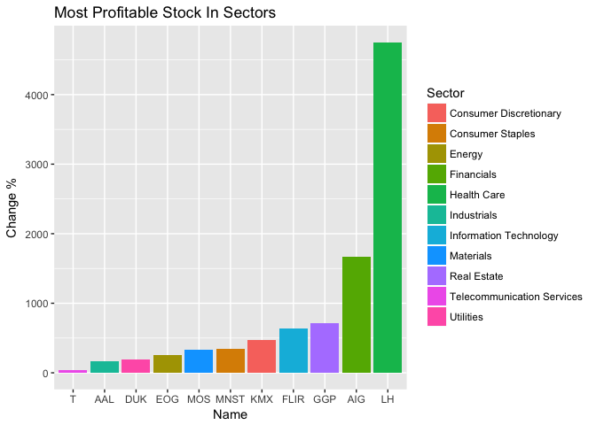

```r
ggplot(one_year, aes(x =reorder(Name, Change), y = Change, fill = Sector)) +
  geom_bar(stat = "identity") +
  ggtitle("Most Profitable Stock In Sectors") +
  xlab("Name") +
  ylab("Change %")
```

```r
# top 10 stocks
one_year = price_first_last_day %>%
  mutate(Change = (End - Start)*100/Start) %>%
  group_by(Name) %>%
  summarise(bnft = max(Change)) %>%
  arrange(-bnft) %>%
  slice(1:10) %>%
  merge(sector)

knitr::kable(one_year,"html")
```

| Name | bnft | Sector |
| --- | --- | --- |
| AIG | 1673.9645 | Financials |
| AKAM | 472.3404 | Information Technology |
| C | 436.9388 | Financials |
| EQIX | 438.3588 | Real Estate |
| ETFC | 769.5652 | Financials |
| FLIR | 639.9024 | Information Technology |
| GGP | 714.0864 | Real Estate |
| KMX | 468.5000 | Consumer Discretionary |
| LH | 4755.1724 | Health Care |
| MSI | 408.1264 | Information Technology |

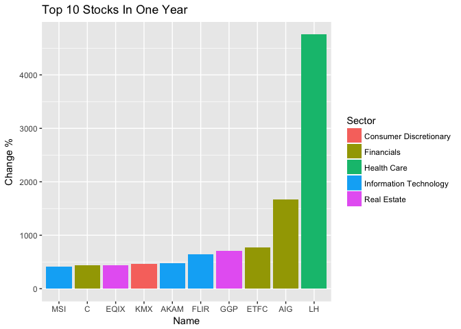

```r
 ggplot(one_year, aes(x =reorder(Name, bnft), y = bnft, fill = Sector)) +
  geom_bar(stat = "identity") +
  ggtitle("Top 10 Stocks In One Year") +
  xlab("Name") +
  ylab("Change %")
```

```r
# in two year
two_years = price_first_last_day %>%
  mutate(Change = (End - Start)/Start)
two_years$Two_Change = 0
for(n in name){
  years = price_first_last_day %>%
    filter(Name == n) %>%
    select(year)
  is_first = TRUE
  for(y in years$year){
    if(is_first){
      two_years[two_years$Name == n & two_years$year == y, ]$Two_Change = 0
      is_first = FALSE
    }
    else {
      two_years[two_years$Name == n & two_years$year == y, ]$Two_Change =
        (two_years[two_years$Name == n & two_years$year == y, ]$End -
        two_years[two_years$Name == n & two_years$year == y-1, ]$Start)*100/
        two_years[two_years$Name == n & two_years$year == y-1, ]$Start
    }
  }
}

two_years_best = two_years %>%
  group_by(Sector) %>%
  arrange(-Two_Change) %>%
  slice(1) %>%
  mutate(start_year = year - 1) %>%
  select(Name, Sector, start_year, end_year = year, Two_Change)

knitr::kable(two_years_best,"html")
```

| Name | Sector | start_year | end_year | Two_Change |
| --- | --- | --- | --- | --- |
| KMX | Consumer Discretionary | 2000 | 2001 | 910.66667 |
| MNST | Consumer Staples | 2004 | 2005 | 851.81161 |
| WMB | Energy | 2003 | 2004 | 477.66059 |
| AIG | Financials | 2009 | 2010 | 3309.46740 |
| LH | Health Care | 2000 | 2001 | 2130.34477 |
| AAL | Industrials | 2012 | 2013 | 393.16406 |
| FLIR | Information Technology | 2001 | 2002 | 852.19510 |
| CF | Materials | 2006 | 2007 | 619.34638 |
| GGP | Real Estate | 2009 | 2010 | 990.14308 |
| T | Telecommunication Services | 2006 | 2007 | 68.19103 |
| AES | Utilities | 2003 | 2004 | 321.91358 |

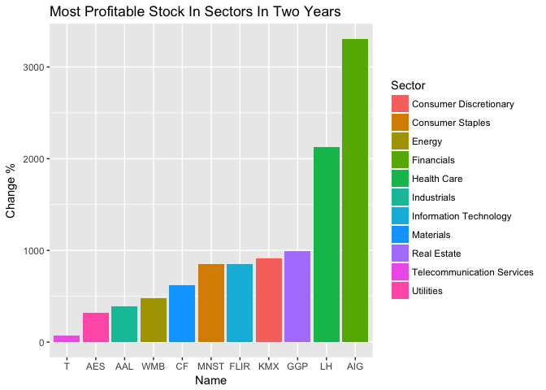

```r
ggplot(two_years_best, aes(x =reorder(Name, Two_Change), y = Two_Change, fill = Sector)) +
  geom_bar(stat = "identity") +
  ggtitle("Most Profitable Stock In Sectors In Two Years") +
  xlab("Name") +
  ylab("Change %")
```

```r
# top 10 stocks
two_years_best = two_years %>%
  group_by(Name) %>%
  arrange(-Two_Change) %>%
  slice(1) %>%
  mutate(start_year = year - 1) %>%
  select(Name, Sector, start_year, end_year = year, Two_Change) %>%
  ungroup() %>%
  arrange(-Two_Change) %>%
  slice(1:10)

knitr::kable(two_years_best,"html")
```

| Name | Sector | start_year | end_year | Two_Change |
| --- | --- | --- | --- | --- |
| AIG | Financials | 2009 | 2010 | 3309.4674 |
| LH | Health Care | 2000 | 2001 | 2130.3448 |
| ETFC | Financials | 2009 | 2010 | 1121.3740 |
| GGP | Real Estate | 2009 | 2010 | 990.1431 |
| EQIX | Real Estate | 2002 | 2003 | 948.6988 |
| KMX | Consumer Discretionary | 2000 | 2001 | 910.6667 |
| FLIR | Information Technology | 2001 | 2002 | 852.1951 |
| MNST | Consumer Staples | 2004 | 2005 | 851.8116 |
| C | Financials | 2011 | 2012 | 707.3470 |
| CF | Materials | 2006 | 2007 | 619.3464 |

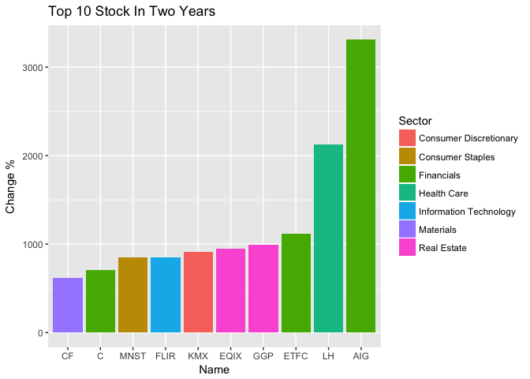

```r
ggplot(two_years_best, aes(x =reorder(Name, Two_Change), y = Two_Change, fill = Sector)) +
  geom_bar(stat = "identity") +
  ggtitle("Top 10 Stock In Two Years") +
  xlab("Name") +
  ylab("Change %")
```

```r
# in five year
five_years = price_first_last_day %>%
  mutate(Change = End - Start)
five_years$Five_Change = 0
for(n in name){
  years = price_first_last_day %>%
    filter(Name == n) %>%
    select(year)
  is_five_first = 1
  for(y in years$year){
    if(is_five_first < 5){
      five_years[five_years$Name == n & five_years$year == y, ]$Five_Change = 0
      is_five_first = is_five_first + 1
    }
    else {
      five_years[five_years$Name == n & five_years$year == y, ]$Five_Change =
        (five_years[five_years$Name == n & five_years$year == y, ]$End -
        five_years[five_years$Name == n & five_years$year == y-4, ]$Start)*100/
        five_years[five_years$Name == n & five_years$year == y-4, ]$Start
    }
  }
}

five_years_best = five_years %>%
  group_by(Sector) %>%
  arrange(-Five_Change) %>%
  slice(1) %>%
  mutate(start_year = year - 4) %>%
  select(Name, Sector, start_year, end_year = year, Five_Change)

knitr::kable(five_years_best,"html")
```

| Name | Sector | start_year | end_year | Five_Change |
| --- | --- | --- | --- | --- |
| KMX | Consumer Discretionary | 2000 | 2004 | 1279.99996 |
| MNST | Consumer Staples | 2001 | 2005 | 1967.14757 |
| WMB | Energy | 2003 | 2007 | 1168.79658 |
| AIG | Financials | 2009 | 2013 | 2920.71000 |
| ISRG | Health Care | 2003 | 2007 | 5195.08197 |
| AAL | Industrials | 2010 | 2014 | 1024.31868 |
| AKAM | Information Technology | 2003 | 2007 | 1740.42543 |
| CF | Materials | 2006 | 2010 | 783.33335 |
| EQIX | Real Estate | 2002 | 2006 | 2711.15253 |
| T | Telecommunication Services | 2003 | 2007 | 43.75649 |
| AES | Utilities | 2003 | 2007 | 560.18515 |

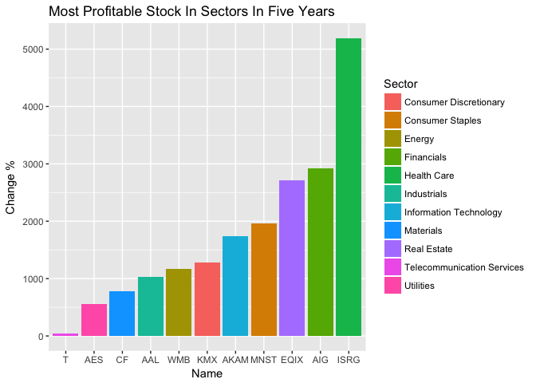

```r
ggplot(five_years_best, aes(x =reorder(Name, Five_Change), y = Five_Change, fill = Sector)) +
  geom_bar(stat = "identity") +
  ggtitle("Most Profitable Stock In Sectors In Five Years") +
  xlab("Name") +
  ylab("Change %")
```

```r
# top 10 stcks
five_years_best = five_years %>%
  group_by(Name) %>%
  arrange(-Five_Change) %>%
  slice(1) %>%
  mutate(start_year = year - 4) %>%
  select(Name, Sector, start_year, end_year = year, Five_Change) %>%
  ungroup() %>%
  arrange(-Five_Change) %>%
  slice(1:10)

knitr::kable(five_years_best,"html")
```

| Name | Sector | start_year | end_year | Five_Change |
| --- | --- | --- | --- | --- |
| ISRG | Health Care | 2003 | 2007 | 5195.082 |
| AIG | Financials | 2009 | 2013 | 2920.710 |
| EQIX | Real Estate | 2002 | 2006 | 2711.153 |
| MNST | Consumer Staples | 2001 | 2005 | 1967.148 |
| AKAM | Information Technology | 2003 | 2007 | 1740.425 |
| ILMN | Health Care | 2003 | 2007 | 1706.707 |
| REGN | Health Care | 2010 | 2014 | 1565.652 |
| C | Financials | 2010 | 2014 | 1491.471 |
| CME | Financials | 2003 | 2007 | 1469.076 |
| ETFC | Financials | 2009 | 2013 | 1399.237 |

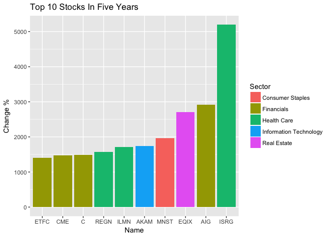

```r
ggplot(five_years_best, aes(x =reorder(Name, Five_Change), y = Five_Change, fill = Sector)) +
  geom_bar(stat = "identity") +
  ggtitle("Top 10 Stocks In Five Years") +
  xlab("Name") +
  ylab("Change %")
```

۲. یک اعتقاد خرافی می گوید خرید سهام در روز سیزدهم ماه زیان آور است. این گزاره را مورد ارزیابی قرار دهید.

جواب:  
در این سوال تعداد شرکت هایی که در روز زیان می کنند مورد ارزیابی قرارگرفته است و روی آن ها t test اعمال شده که نتیجه برابر را نمی تواند رد کند پس می توان گفت فرقی در این روز خاص با روز های دیگر وجود ندارد.

```r
sp500_superstition = sp500 %>%
  mutate(bad_day = ifelse(100*((Close - Open)/Open)<0,1,0)) %>%
  group_by(year, month, day, bad_day) %>%
  summarise(c_jump = n())

thirteen = sp500_superstition %>% filter(day == 13) %>%
  ungroup() %>%
  group_by(year, month, day) %>%
  mutate(fall_rate_company = c_jump/sum(c_jump)) %>%
  filter(bad_day == 1)
non_thirteen = sp500_superstition %>% filter(day != 13) %>%
  ungroup() %>%
  group_by(year, month, day) %>%
  mutate(fall_rate_company = c_jump/sum(c_jump)) %>%
  filter(bad_day == 1)

t.test(thirteen$fall_rate_company, non_thirteen$fall_rate_company, alt = "two.sided")
```

```
    Welch Two Sample t-test

data:  thirteen$fall_rate_company and non_thirteen$fall_rate_company
t = 0.67082, df = 151.57, p-value = 0.5034
alternative hypothesis: true difference in means is not equal to 0
95 percent confidence interval:
 -0.02531103  0.05133452
sample estimates:
mean of x mean of y
0.4969337 0.4839220
```

۳. رکورد بیشترین گردش مالی در تاریخ بورس برای چه روزی بوده است و چرا!!!

```r
max_working_capital_v = sp500 %>%
  group_by(year, month, day) %>%
  summarise(working_capital = sum(as.numeric(Volume))) %>%
  arrange(-working_capital) %>%
  ungroup() %>%
  slice(1)

knitr::kable(max_working_capital_v,"html")
```

| year | month | day | working_capital |
| --- | --- | --- | --- |
| 2008 | 10 | 10 | 8896471300 |

```r
max_working_capital = sp500 %>%
  mutate(wc = as.numeric(Volume)*(as.numeric(Open + Close)/2)) %>%
  group_by(Date) %>%
  summarise(working_capital = sum(wc)) %>%
  arrange(-working_capital) %>%
  slice(1)

knitr::kable(max_working_capital,"html")
```

| Date | working_capital |
| --- | --- |
| 2008-01-23 | 388315324390 |

۴. شاخص AAPL که نماد شرکت اپل است را در نظر بگیرید. با استفاده از رگرسیون خطی یک پیش کننده قیمت شروع (open price) بر اساس k روز قبل بسازید. بهترین انتخاب برای k چه مقداری است؟ دقت پیش بینی شما چقدر است؟

جواب:  
برای محاسبه ی این مدل ها مقادیر روز های قبل برای یک روز ایجاد شد که شما در صورت لزوم تا ده روز قبل را در جلوی یک روز در اختیار دارید. همانطور که مشاهده می کنید بهترین انتخاب برای ده روز قبل است که کمترین خطا را دارد اما تغییر زیادی در آن مشاهده نمی شود.

```r
apple_stock = sec_sp500 %>%
  filter(Name == "AAPL") %>%
  select(year, month, day, Open) %>%
  arrange(year, month, day)

apple_stock_k = apple_stock
apple_stock_k$k_1 = c(0, head(apple_stock_k$Open, -1))
apple_stock_k$k_2 = c(0,0, head(apple_stock_k$Open, -2))
apple_stock_k$k_3 = c(0,0,0, head(apple_stock_k$Open, -3))
apple_stock_k$k_4 = c(0,0,0,0, head(apple_stock_k$Open, -4))
apple_stock_k$k_5 = c(0,0,0,0,0, head(apple_stock_k$Open, -5))
apple_stock_k$k_6 = c(0,0,0,0,0,0, head(apple_stock_k$Open, -6))
apple_stock_k$k_7 = c(0,0,0,0,0,0,0, head(apple_stock_k$Open, -7))
apple_stock_k$k_8 = c(0,0,0,0,0,0,0,0, head(apple_stock_k$Open, -8))
apple_stock_k$k_9 = c(0,0,0,0,0,0,0,0,0, head(apple_stock_k$Open, -9))
apple_stock_k$k_10 = c(0,0,0,0,0,0,0,0,0,0, head(apple_stock_k$Open, -10))

lm_1 = lm(data = apple_stock_k, formula = Open~k_1)
lm_2 = lm(data = apple_stock_k, formula = Open~k_1+k_2)
lm_3 = lm(data = apple_stock_k, formula = Open~k_1+k_2+k_3)
lm_4 = lm(data = apple_stock_k, formula = Open~k_1+k_2+k_3+k_4)
lm_5 = lm(data = apple_stock_k, formula = Open~k_1+k_2+k_3+k_4+k_5)
lm_6 = lm(data = apple_stock_k, formula = Open~k_1+k_2+k_3+k_4+k_5+k_6)
lm_7 = lm(data = apple_stock_k, formula = Open~k_1+k_2+k_3+k_4+k_5+k_6+k_7)
lm_8 = lm(data = apple_stock_k, formula = Open~k_1+k_2+k_3+k_4+k_5+k_6+k_7+k_8)
lm_9 = lm(data = apple_stock_k, formula = Open~k_1+k_2+k_3+k_4+k_5+k_6+k_7+k_8+k_9)
lm_10 = lm(data = apple_stock_k, formula = Open~k_1+k_2+k_3+k_4+k_5+k_6+k_7+k_8+k_9+k_10)
summary(lm_10)
```

```
Call:
lm(formula = Open ~ k_1 + k_2 + k_3 + k_4 + k_5 + k_6 + k_7 +
    k_8 + k_9 + k_10, data = apple_stock_k)

Residuals:
    Min      1Q  Median      3Q     Max
-555.54   -1.14   -0.10    1.33  104.57

Coefficients:
              Estimate Std. Error t value Pr(>|t|)
(Intercept)  0.3068741  0.2131838   1.439   0.1501
k_1          0.9703601  0.0153097  63.382   <2e-16 ***
k_2          0.0264655  0.0213328   1.241   0.2148
k_3         -0.0179822  0.0213367  -0.843   0.3994
k_4          0.0394071  0.0213382   1.847   0.0648 .
k_5         -0.0061337  0.0213430  -0.287   0.7738
k_6         -0.0262799  0.0213430  -1.231   0.2183
k_7         -0.0065004  0.0213383  -0.305   0.7607
k_8         -0.0009711  0.0213367  -0.046   0.9637
k_9          0.0095610  0.0213329   0.448   0.6540
k_10         0.0104460  0.0153082   0.682   0.4950
---
Signif. codes:  0 '***' 0.001 '**' 0.01 '*' 0.05 '.' 0.1 ' ' 1

Residual standard error: 9.935 on 4266 degrees of freedom
Multiple R-squared:  0.9967,    Adjusted R-squared:  0.9967
F-statistic: 1.301e+05 on 10 and 4266 DF,  p-value: < 2.2e-16
```

```r
# clac Mean Squared Error
e_1 = summary(lm_1)
mean(e_1$residuals^2)
```

```
[1] 98.72352
```

```r
e_2 = summary(lm_2)
mean(e_2$residuals^2)
```

```
[1] 98.64951
```

```r
e_3 = summary(lm_3)
mean(e_3$residuals^2)
```

```
[1] 98.64934
```

```r
e_4 = summary(lm_4)
mean(e_4$residuals^2)
```

```
[1] 98.60856
```

```r
e_5 = summary(lm_5)
mean(e_5$residuals^2)
```

```
[1] 98.57137
```

```r
e_6 = summary(lm_6)
mean(e_6$residuals^2)
```

```
[1] 98.55105
```

```r
e_7 = summary(lm_7)
mean(e_7$residuals^2)
```

```
[1] 98.53746
```

```r
e_8 = summary(lm_8)
mean(e_8$residuals^2)
```

```
[1] 98.50395
```

```r
e_9 = summary(lm_9)
mean(e_9$residuals^2)
```

```
[1] 98.46571
```

```r
e_10 = summary(lm_10)
mean(e_10$residuals^2)
```

```
[1] 98.45496
```

۵. بر روی داده های قیمت شروع شرکت ها الگوریتم pca را اعمال کنید. نمودار تجمعی درصد واریانس بیان شده در مولفه ها را رسم کنید. سه مولفه اول چند درصد از واریانس را تبیین می کند؟

جواب:  
میزان ۷۹.۷۶ درصدی ۳ مولفه ی اول را مشاهده می کنید.

```
integer(0)
```

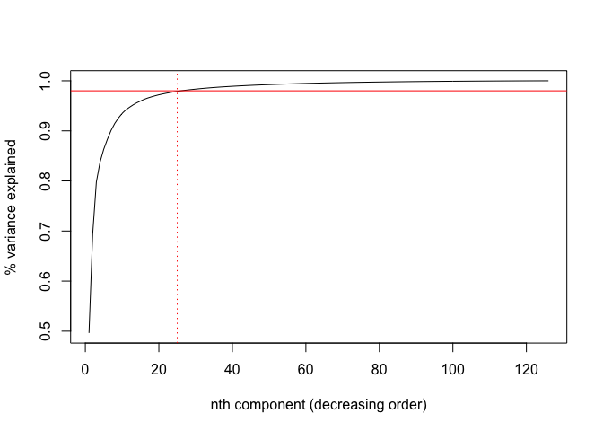

```r
sp500_pca_dmy = sp500_pca %>%
  select(-year, -month, -day, -Date)
stocks_pca = prcomp(sp500_pca_dmy, scale. = TRUE)

plot(summary(stocks_pca)$importance[3,], type="l",
     ylab="% variance explained", xlab="nth component (decreasing order)") +
  abline(h=0.98,col="red");abline(v = 25,col="red",lty=3)
```

```r
# first three comp.
sum((stocks_pca$sdev^2)[1:3])/sum((stocks_pca$sdev^2))
```

```
[1] 0.7976489
```

۶. برای هر نماد اطلاعات بخش مربوطه را از داده constituents استخراج نمایید. برای هر بخش میانگین روزانه قیمت شروع شرکت های آن را محاسبه کنید. سپس با استفاده از میانگین به دست آمده داده ایی با چند ستون که هر ستون یک بخش و هر سطر یک روز هست بسازید. داده مربوط را با داده شاخص های اقتصادی ادغام کنید. بر روی این داده pca بزنید و نمودار biplot آن را تفسیر کنید.

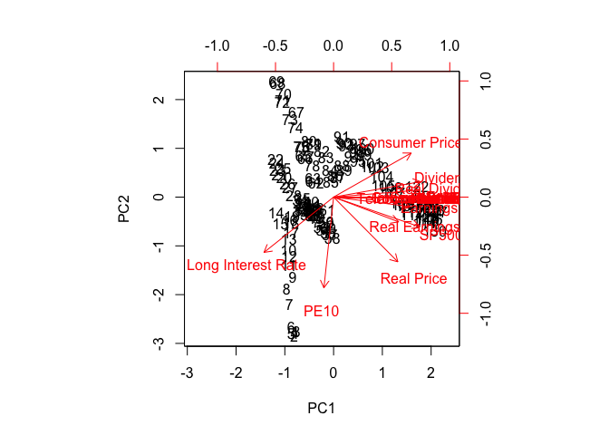

```r
sec_mean_open = sec_sp500 %>%
  ungroup() %>%
  group_by(Sector,Date) %>%
  summarise(mean_open = mean(Open))

sectors = sec_mean_open %>%
  ungroup() %>%
  select(Sector) %>%
  distinct()

.data = sec_mean_open %>%
  ungroup() %>%
  filter(Sector == sectors[[1]][1]) %>%
  select(Date, mean_open)
colnames(.data) =c("Date", sectors[[1]][1])
sec_sp500_pca = .data

for(i in 2:11){
  .data <- sec_mean_open %>%
    ungroup() %>%
    filter(Sector == sectors[[1]][1]) %>%
    select(Date, mean_open)
  colnames(.data) =c("Date", sectors[[1]][i])
  sec_sp500_pca = merge(sec_sp500_pca, .data)
}

sec_sp500_pca = merge(sec_sp500_pca, indexes)
sec_sp500_pca = sec_sp500_pca %>%
  select(-Date)
sec_index_stock_pca = prcomp(sec_sp500_pca, scale. = TRUE)
biplot(sec_index_stock_pca, scale = 1, pc.biplot = TRUE)
```

۷. روی همه اطلاعات (OHLCV) سهام اپل الگوریتم PCA را اعمال کنید. سپس از مولفه اول برای پیش بینی قیمت شروع سهام در روز آینده استفاده کنید. به سوالات سوال ۴ پاسخ دهید. آیا استفاده از مولفه اول نتیجه بهتری نسبت به داده open price برای پیش بینی قیمت دارد؟

```r
library(rpart)

apple_ohlcv = sp500 %>%
  filter(Name == "AAPL") %>%
  arrange(Date) %>%
  select(Open, High, Low, Close, Volume)

apple_pca = prcomp(apple_ohlcv, scale. = TRUE)

train = data.frame(open_price = apple_ohlcv$Open, apple_pca$x)
# only first pc
train = train[,1:2]
# linear model
lm_aapl = lm(open_price ~ PC1 ,data = train)
summary(lm_aapl)
```

```
Call:
lm(formula = open_price ~ PC1, data = train)

Residuals:
     Min       1Q   Median       3Q      Max
-13.2934  -0.9153  -0.3509   0.7083  17.1712

Coefficients:
             Estimate Std. Error t value Pr(>|t|)
(Intercept) 170.52939    0.03245    5255   <2e-16 ***
PC1          86.79590    0.01623    5349   <2e-16 ***
---
Signif. codes:  0 '***' 0.001 '**' 0.01 '*' 0.05 '.' 0.1 ' ' 1

Residual standard error: 2.122 on 4275 degrees of freedom
Multiple R-squared:  0.9999,    Adjusted R-squared:  0.9999
F-statistic: 2.861e+07 on 1 and 4275 DF,  p-value: < 2.2e-16
```

```r
# decision tree
rp_mdl = rpart(open_price ~ .,data = train, method = "anova")
pred = predict(rp_mdl,newdata = train)
train$pred = pred
res = train %>%
  mutate(dif = (open_price - pred)^2) %>%
  summarise(mean(dif))
res[[1]][1]
```

```
[1] 969.033
```

```r
apple_stock_k$Open = train$PC1
apple_stock_k$k_1 = c(0, head(apple_stock_k$Open, -1))
apple_stock_k$k_2 = c(0,0, head(apple_stock_k$Open, -2))
apple_stock_k$k_3 = c(0,0,0, head(apple_stock_k$Open, -3))
apple_stock_k$k_4 = c(0,0,0,0, head(apple_stock_k$Open, -4))
apple_stock_k$k_5 = c(0,0,0,0,0, head(apple_stock_k$Open, -5))
apple_stock_k$k_6 = c(0,0,0,0,0,0, head(apple_stock_k$Open, -6))
apple_stock_k$k_7 = c(0,0,0,0,0,0,0, head(apple_stock_k$Open, -7))
apple_stock_k$k_8 = c(0,0,0,0,0,0,0,0, head(apple_stock_k$Open, -8))
apple_stock_k$k_9 = c(0,0,0,0,0,0,0,0,0, head(apple_stock_k$Open, -9))
apple_stock_k$k_10 = c(0,0,0,0,0,0,0,0,0,0, head(apple_stock_k$Open, -10))

lm_1 = lm(data = apple_stock_k, formula = Open~k_1)
lm_2 = lm(data = apple_stock_k, formula = Open~k_1+k_2)
lm_3 = lm(data = apple_stock_k, formula = Open~k_1+k_2+k_3)
lm_4 = lm(data = apple_stock_k, formula = Open~k_1+k_2+k_3+k_4)
lm_5 = lm(data = apple_stock_k, formula = Open~k_1+k_2+k_3+k_4+k_5)
lm_6 = lm(data = apple_stock_k, formula = Open~k_1+k_2+k_3+k_4+k_5+k_6)
lm_7 = lm(data = apple_stock_k, formula = Open~k_1+k_2+k_3+k_4+k_5+k_6+k_7)
lm_8 = lm(data = apple_stock_k, formula = Open~k_1+k_2+k_3+k_4+k_5+k_6+k_7+k_8)
lm_9 = lm(data = apple_stock_k, formula = Open~k_1+k_2+k_3+k_4+k_5+k_6+k_7+k_8+k_9)
lm_10 = lm(data = apple_stock_k, formula = Open~k_1+k_2+k_3+k_4+k_5+k_6+k_7+k_8+k_9+k_10)
summary(lm_10)
```

```
Call:
lm(formula = Open ~ k_1 + k_2 + k_3 + k_4 + k_5 + k_6 + k_7 +
    k_8 + k_9 + k_10, data = apple_stock_k)

Residuals:
    Min      1Q  Median      3Q     Max
-6.3801 -0.0098  0.0001  0.0129  0.5906

Coefficients:
              Estimate Std. Error t value Pr(>|t|)
(Intercept) -0.0001470  0.0016644  -0.088   0.9296
k_1          1.0265975  0.0153090  67.058   <2e-16 ***
k_2         -0.0384075  0.0219409  -1.750   0.0801 .
k_3          0.0000299  0.0219482   0.001   0.9989
k_4          0.0136722  0.0219480   0.623   0.5334
k_5          0.0088030  0.0219476   0.401   0.6884
k_6         -0.0158482  0.0219476  -0.722   0.4703
k_7         -0.0064868  0.0219480  -0.296   0.7676
k_8         -0.0104891  0.0219482  -0.478   0.6327
k_9          0.0067829  0.0219409   0.309   0.7572
k_10         0.0139154  0.0153092   0.909   0.3634
---
Signif. codes:  0 '***' 0.001 '**' 0.01 '*' 0.05 '.' 0.1 ' ' 1

Residual standard error: 0.1088 on 4266 degrees of freedom
Multiple R-squared:  0.997, Adjusted R-squared:  0.997
F-statistic: 1.439e+05 on 10 and 4266 DF,  p-value: < 2.2e-16
```

```r
# clac Mean Squared Error
e_1 = summary(lm_1)
mean(e_1$residuals^2)
```

```
[1] 0.01184045
```

```r
e_2 = summary(lm_2)
mean(e_2$residuals^2)
```

```
[1] 0.01183087
```

```r
e_3 = summary(lm_3)
mean(e_3$residuals^2)
```

```
[1] 0.01182951
```

```r
e_4 = summary(lm_4)
mean(e_4$residuals^2)
```

```
[1] 0.0118282
```

```r
e_5 = summary(lm_5)
mean(e_5$residuals^2)
```

```
[1] 0.01182804
```

```r
e_6 = summary(lm_6)
mean(e_6$residuals^2)
```

```
[1] 0.01182623
```

```r
e_7 = summary(lm_7)
mean(e_7$residuals^2)
```

```
[1] 0.01182608
```

```r
e_8 = summary(lm_8)
mean(e_8$residuals^2)
```

```
[1] 0.01182474
```

```r
e_9 = summary(lm_9)
mean(e_9$residuals^2)
```

```
[1] 0.01181949
```

```r
e_10 = summary(lm_10)
mean(e_10$residuals^2)
```

```
[1] 0.01181721
```

۸. نمودار سود نسبی شاخص s&p500 را رسم کنید. آیا توزیع سود نرمال است؟(از داده indexes استفاده کنید.) با استفاده از ده مولفه اول سوال پنج آیا می توانید سود و ضرر شاخص s&p500 را برای روز آينده پیش بینی کنید؟ از یک مدل رگرسیون لاجستیک استفاده کنید. درصد خطای پیش بینی را به دست آورید.

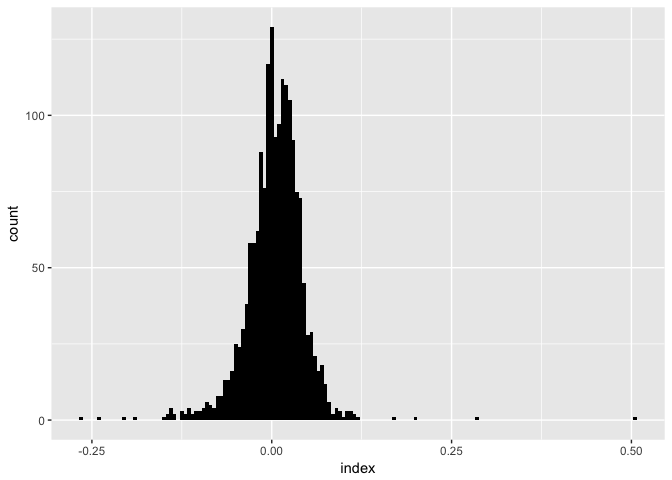

```r
ind = indexes %>%
  select(real_price = `Real Price`,sp500 = SP500) %>%
  mutate(index = (sp500-lag(sp500))/lag(sp500))
ggplot(ind,aes(index)) + geom_histogram(binwidth = 0.005, fill = 'black')
```

```r
ind = merge(indexes, sp500_pca)
index_pca = data.frame(sp500_pca, stocks_pca$x)
index_pca = merge(index_pca,ind)
index_pca = index_pca %>%
  select(-Date)
glm_sp500 = glm(data = index_pca, formula = SP500 ~ PC1+PC2)
summary(glm_sp500)
```

```
Call:
glm(formula = SP500 ~ PC1 + PC2, data = index_pca)

Deviance Residuals:
      1        2        3        4
 4.7350  -8.2570   3.3578   0.1642

Coefficients:
             Estimate Std. Error t value Pr(>|t|)
(Intercept) 2185.3160     5.0513 432.622  0.00147 **
PC1            2.2278     0.3289   6.774  0.09331 .
PC2           -2.1834     0.6243  -3.497  0.17730
---
Signif. codes:  0 '***' 0.001 '**' 0.01 '*' 0.05 '.' 0.1 ' ' 1

(Dispersion parameter for gaussian family taken to be 101.8991)

    Null deviance: 5141.9  on 3  degrees of freedom
Residual deviance:  101.9  on 1  degrees of freedom
AIC: 32.302

Number of Fisher Scoring iterations: 2
```

۹. عکسی که در ابتدای متن آمده را در نظر بگیرید. با استفاده از pca عکس را فشرده کنید. سپس نمودار حجم عکس فشرده بر حسب تعداد مولفه اصلی را رسم کنید. بهترین انتخاب برای انتخاب تعداد مولفه ها در جهت فشرده سازی چه عددی است؟

```
integer(0)
```

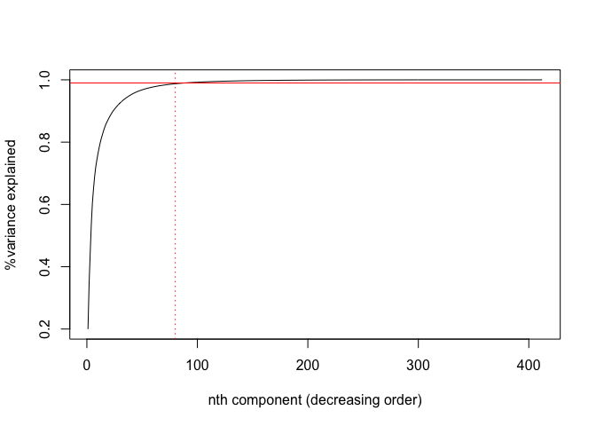

```r
library("EBImage")
pic = flip(readImage("images/stock.jpg"))

img1 <- pic[ , , 1]
img2 <- pic[ , , 2]
img3 <- pic[ , , 3]

pca.img1 <- prcomp(img1 , scale = T)
pca.img2 <- prcomp(img2 , scale = T)
pca.img3 <- prcomp(img3 , scale = T)

plot(summary(pca.img1)$importance[3,], type="l",
     ylab="%variance explained", xlab="nth component (decreasing order)") +
  abline(h=0.99,col="red");abline(v = 80,col="red",lty=3)
```

```
integer(0)
```

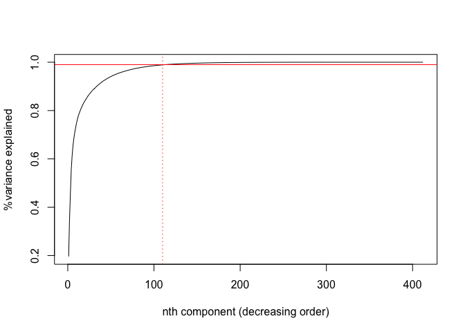

```r
plot(summary(pca.img2)$importance[3,], type="l",
     ylab="%variance explained", xlab="nth component (decreasing order)") +
  abline(h=0.99,col="red");abline(v = 110,col="red",lty=3)
```

```
integer(0)
```

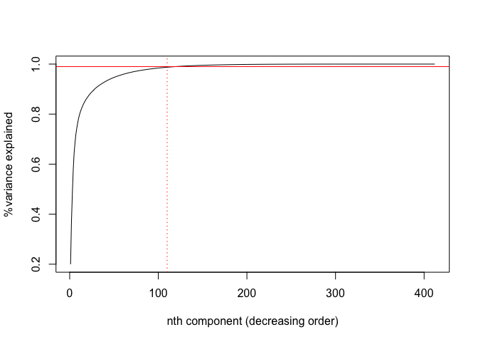

```r
plot(summary(pca.img3)$importance[3,], type="l",
     ylab="%variance explained", xlab="nth component (decreasing order)") +
  abline(h=0.99,col="red");abline(v = 110,col="red",lty=3)
```

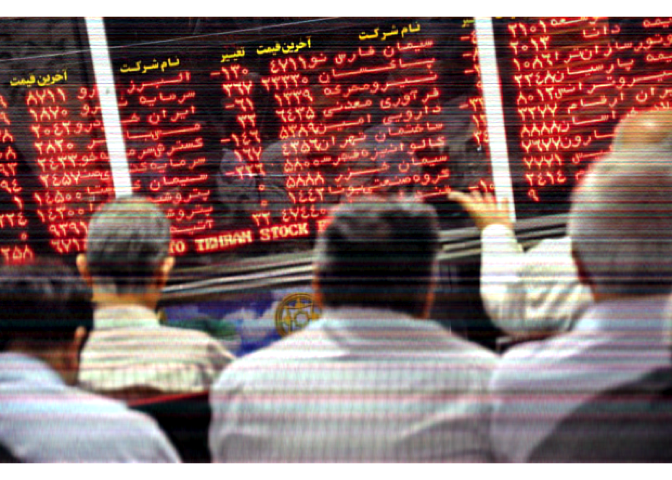

```r
chosen.components = 1:110
feature.vector1 = pca.img1$rotation[,chosen.components]
feature.vector2 = pca.img2$rotation[,chosen.components]
feature.vector3 = pca.img3$rotation[,chosen.components]

compact.data1 = t(feature.vector1) %*% t(img1)
compact.data2 = t(feature.vector2) %*% t(img2)
compact.data3 = t(feature.vector3) %*% t(img3)

approx.img1 = t(feature.vector1 %*% compact.data1)
approx.img2 = t(feature.vector2 %*% compact.data2)
approx.img3 = t(feature.vector3 %*% compact.data3)

pic[ , , 1] <- approx.img1
pic[ , , 2] <- approx.img2
pic[ , , 3] <- approx.img3
plot(flip(pic))
```

جواب:  
در این جا به صورت میانگین مقدار ۱۱۰ را در نظر می گیریم.

۱۰. پنج ایده جالبی که روی داده های مالی بالا می توانستیم پیاده کنیم را بیان کنید. (ایده کافی است نیازی به محاسبه بر روی داده نیست.)

جواب:  
۱.بررسی توالی قله ها و سقوط های یک سهام برای پیش بینی سقوط بعدی یا صعود بعدی  
۲. بررسی و پیش بینی سبد سهام برای سود حداکثری  
۳.بدست آوردن حاشیه ی امنیت برای نگه داشتن یک سهام بر اساس میزان رشد  
۴. محاسبه ی ترندهای تکنولوژی در هر بخش بر اساس میزان اقبال به یک سهام در یک بخش با درنظر گرفتن حجم معاملات  
۵.بررسی دره ها در جهت پیش بینی بهترین زمان خرید سهام